# Linear Regression

# Running a Multivariate Regression

Using the Ordinary Least Square OLS Model

```python
y = customers['Yearly Amount Spent']
```

```python
X = customers[['Avg. Session Length', 'Time on App','Time on Website', 'Length of Membership']]
```

```python
x1 = sm.add_constant(X)
```

```python
reg = sm.OLS(y, x1).fit()
```

```python
reg.summary()
```

OLS Regression Results

| Dep. Variable: | Yearly Amount Spent | R-squared: | 0.984 |
| --- | --- | --- | --- |
| Model: | OLS | Adj. R-squared: | 0.984 |
| Method: | Least Squares | F-statistic: | 7766. |
| Date: | Tue, 30 Oct 2018 | Prob (F-statistic): | 0.00 |
| Time: | 22:25:18 | Log-Likelihood: | -1856.9 |
| No. Observations: | 500 | AIC: | 3724. |
| Df Residuals: | 495 | BIC: | 3745. |
| Df Model: | 4 |  |  |
| Covariance Type: | nonrobust |  |  |

|  | coef | std err | t | P>\|t\| | [0.025 | 0.975] |
| --- | --- | --- | --- | --- | --- | --- |
| const | -1051.5943 | 22.993 | -45.736 | 0.000 | -1096.769 | -1006.419 |
| Avg. Session Length | 25.7343 | 0.451 | 57.057 | 0.000 | 24.848 | 26.620 |
| Time on App | 38.7092 | 0.451 | 85.828 | 0.000 | 37.823 | 39.595 |
| Time on Website | 0.4367 | 0.444 | 0.983 | 0.326 | -0.436 | 1.309 |
| Length of Membership | 61.5773 | 0.448 | 137.346 | 0.000 | 60.696 | 62.458 |

| Omnibus: | 0.337 | Durbin-Watson: | 1.887 |
| --- | --- | --- | --- |
| Prob(Omnibus): | 0.845 | Jarque-Bera (JB): | 0.198 |
| Skew: | -0.026 | Prob(JB): | 0.906 |
| Kurtosis: | 3.083 | Cond. No. | 2.64e+03 |

Warnings:  
[1] Standard Errors assume that the covariance matrix of the errors is correctly specified.  
[2] The condition number is large, 2.64e+03. This might indicate that there are  
strong multicollinearity or other numerical problems.

As we can see, our model performed very well R-squared = 0.984 Adj.R-squared = 0.984

Interpreting the coefficients:

- Holding all other features fixed, a 1 unit increase in **Avg. Session Length** is associated with an **increase of 25.74 total dollars spent**.
- Holding all other features fixed, a 1 unit increase in **Time on App** is associated with an **increase of 38.70 total dollars spent**.
- Holding all other features fixed, a 1 unit increase in **Time on Website** is associated with an **increase of 0.44 total dollars spent**.
- Holding all other features fixed, a 1 unit increase in **Length of Membership** is associated with an **increase of 61.58 total dollars spent**.

```python
# Let us do the same with SKlearn
```

**Use model_selection.train_test_split from sklearn to split the data into training and testing sets. Set test_size=0.3 and random_state=101**

```python
X_train, X_test, y_train, y_test = train_test_split(X, y, test_size=0.3, random_state=101)
```

**Create an instance of a LinearRegression() model named lm.**

```python
lm = LinearRegression()
```

```python
lm.fit(X_train,y_train)
```

```
LinearRegression(copy_X=True, fit_intercept=True, n_jobs=1, normalize=False)
```

```python
# The coefficients
print('Coefficients: \n', lm.coef_)
```

```
Coefficients:
 [25.98154972 38.59015875  0.19040528 61.27909654]
```

If we were to compare the two models, we can see that both sets of coefficients are quite similar except for time on website, which are 0.44 and 0.19. This due to random_state

## Predicting Test Data

Now that we have fit our model, let's evaluate its performance by predicting off the test values!

**Use lm.predict() to predict off the X_test set of the data.**

```python
predictions = lm.predict( X_test)
```

Create a scatterplot of the real test values versus the predicted values.

```
Text(0,0.5,'Predicted Y')
```

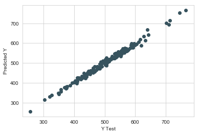

```python
plt.scatter(y_test,predictions)
plt.xlabel('Y Test')
plt.ylabel('Predicted Y')
```

## Evaluating the Model

** Calculate the Mean Absolute Error, Mean Squared Error, and the Root Mean Squared Error.

```python
# calculate these metrics by hand!
from sklearn import metrics

print('MAE:', metrics.mean_absolute_error(y_test, predictions))
print('MSE:', metrics.mean_squared_error(y_test, predictions))
print('RMSE:', np.sqrt(metrics.mean_squared_error(y_test, predictions)))
```

```
MAE: 7.228148653430853
MSE: 79.81305165097487
RMSE: 8.933815066978656
```

[output not shown]

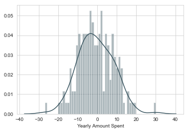

```python
sns.distplot((y_test-predictions),bins=50);
```

## Conclusion

**Recreate the dataframe below.**

```python
coeffecients = pd.DataFrame(lm.coef_,X.columns)
coeffecients.columns = ['Coeffecient']
coeffecients
```

|  | Coeffecient |
| --- | --- |
| Avg. Session Length | 25.98 |
| Time on App | 38.59 |
| Time on Website | 0.19 |
| Length of Membership | 61.28 |

Interpreting the coefficients:

- Holding all other features fixed, a 1 unit increase in **Avg. Session Length** is associated with an **increase of 25.98 total dollars spent**.
- Holding all other features fixed, a 1 unit increase in **Time on App** is associated with an **increase of 38.59 total dollars spent**.
- Holding all other features fixed, a 1 unit increase in **Time on Website** is associated with an **increase of 0.19 total dollars spent**.
- Holding all other features fixed, a 1 unit increase in **Length of Membership** is associated with an **increase of 61.27 total dollars spent**.